# Introduction aux marchés financiers à temps discret et au pricing de produits financiers

# 2 Le rôle des marchés financiers

Les marchés financiers remplissent trois fonctions essentielles :

1. **Les transferts de capitaux** : Deux catégories d’agents coexistent : les agents à capacité de financement (investisseurs : ménages, institutions) et ceux à besoin de financement (entreprises, États, collectivités). Le marché assure la rencontre entre ces acteurs en organisant le transfert des capitaux via l’émission et l’achat de titres financiers (actions, obligations). Ce mécanisme permet de transformer l’épargne en investissements productifs.
2. **La gestion et le transfert des risques** : Ils offrent aux acteurs économiques des produits pour couvrir, mutualiser ou transférer leurs risques. Cette fonction contribue à stabiliser les positions des investisseurs et des emprunteurs face aux aléas des marchés.  
   *Exemple : les assurances, la couverture avec des produits dérivés comme les futures ou les options de vente*
3. **Un Rôle informationnel** : Les marchés financiers génèrent en continu de l’information sur la valeur des entreprises et la perception des risques. Les prix de marché (actions, obligations, etc.) constituent ainsi des signaux reflétant la santé économique de ces entreprises et de l’économie en général.  
   Ce rôle est formalisé par l’**Hypothèse des Marchés Efficients**, selon laquelle les prix intègrent instantanément toute l’information disponible passée. En pratique, cette hypothèse admet des limites : les prix peuvent s’écarter de la valeur fondamentale à court terme, car ils sont déterminés par le mécanisme de l’offre et de la demande et non par des indicateurs comme le chiffre d’affaires.

# 3 Vocabulaire

Flux de trésorerie (Cash flow)

Transfert d’une somme d’argent entre deux agents. Un flux positif représente un **encaissement** pour le bénéficiaire, un flux négatif un **décaissement**.

Titre financier (Security / Financial claim)

Actif conférant à son détenteur le droit à une **séquence de flux de trésorerie futurs**. Il est défini par :

- Le nombre et les dates (déterministes ou aléatoires) des flux.
- La nature des flux : **déterministes** (titre sans risque) ou **aléatoires** (titre risqué).
- La monnaie de libellé(numéraire) dans laquelle les flux sont payés.

## 3.1 Type de produits financiers:

- **Actions (Stocks)** : Titres de propriété - Part du capital d’une entreprise donnant droit à son propriétaire de percevoir des dividendes et de participer aux décisions de l’entreprise.
- **Obligations (Bonds)** : Titres de créance. - Forme spécifique de prêt émis pour lever des fonds importants sur des maturités longues (10-20 ans).
  - **Mécanisme de base** :
    - À l’émission : l’investisseur paie le prix d’émission $I$ à l’émetteur
    - Périodiquement : l’émetteur verse un coupon $C = N \times z$  
      ($N$ = nominal, $z$ = taux d’intérêt)
    - À l’échéance : l’émetteur rembourse le montant $R$
  - **Caractéristiques principales** :
    - Prix d’émission ($I$) : Montant effectivement payé par l’investisseur.
    - Nominal ($N$) : Capital emprunté.
    - Taux d’intérêt ($z$) : Taux contractuel utilisé pour calculer les coupons.
    - Coupons ($C$) : Paiements périodiques.
    - Montant de remboursement ($R$) : Somme versée à l’échéance.
    - Maturité ($T$) : Date de remboursement du nominal.
  - **Termes complémentaires** :
    - Émission **au pair** : $I = N$
    - Émission **en dessous du pair** : $I < N$
    - Émission **au-dessus du pair** : $I > N$
    - Remboursement au pair : $R = N$.
- **Obligation à coupon zéro (Zero-coupon bond)** : Obligation avec taux d’intérêt zéro (z = 0).
- **Produit dérivés** : Contrat financier
  - **Contrat à terme (Future/Forward)** : Contrat où une partie **s’engage** à acheter/vendre un actif à une date future T à un prix fixé K (le strike).
  - **Option** : **Droit** (non obligation) d’acheter (call) ou de vendre (put) un actif à une date future à un prix prédéterminé.
    - Payoff du Call Européen : $h_C(S_T) = \max\{S_T - K, 0\} = (S_T - K)_+$.
    - Payoff du Put Européen : $h_P(S_T) = \max\{K - S_T, 0\} = (K - S_T)_+$.

# 4 Taux d’Intérêt et Actualisation

Le taux d’intérêt est le prix payé pour l’utilisation de l’argent d’autrui sur une période donnée. Il représente la compensation pour le report de consommation. Nous nous intéressons principalement aux intérêts composés.

Taux Composé et Capitalisation

Les intérêts composés (compound interest) se calculent non seulement sur le capital initial, mais aussi sur les intérêts accumulés des périodes précédentes. La **Valeur Future ($F_V$)** d’un capital initial $I_C$ après $T$ périodes est :

$$F_{V} = I_{C}
\prod_{k=0}^{T-1}(1+r_{k})$$

où $r_k$ est le taux d’intérêt pour la période $k$.

Pour un taux $r$ constant, la formule se simplifie en :

$$F_V = I_C(1+r)^T$$

Ce qui représente la capitalisation des intérêts sur plusieurs périodes.

L’actualisation (discounting) répond à la question : **“Que vaut aujourd’hui un euro reçu dans le futur ?”**. Elle permet de comparer différents flux à différentes dates en les ramenenant à une date commune.

Actualisation (Discounting)

La **Valeur Actualisée ($V$)** d’un flux $F$ à recevoir à l’instant $t'$, évaluée à l’instant $t$, est :

$$V=\frac{F}{\prod_{k=t}^{t^{\prime}-1}(1+r_{k})}$$

où $r_k$ est le taux d’actualisation pour la période $k$.

Le **Facteur d’Actualisation** entre les dates $t$ et $t'$ est défini par :

$$D(t, t') =
\prod_{k=t}^{t^{\prime}-1}(1+r_{k})^{-1}$$

Ce facteur permet de ramener un flux futur à sa valeur présente.

# 5 Une Première Approche du Pricing : Cadre Non-Aléatoire

## 5.1 Introduction à la notion d’Arbitrage

Afin d’aborder cette première approche de pricing dans un cadre déterministe, il nous faut d’abord définir la notion d’arbitrage. Elle sera ensuite reprise plus en détail dans la suite du rapport pour le model probabiliste.

Opportunité d’Arbitrage (AO)

Une stratégie d’investissement $(X_0, \pi)$ est une opportunité d’arbitrage si elle satisfait les trois conditions :

**1. Capital initial nul** : $X_0 = 0$  
Aucun investissement personnel requis au départ.

**2. Gain non-négatif certain** : $\mathbb{P}[X_T \ge 0] = 1$  
Absence de risque de perte à l’horizon $T$.

**3. Gain strictement positif possible** : $\mathbb{P}[X_T > 0] > 0$  
Probabilité non nulle de réaliser un profit.

En résumé : Une AO permet de réaliser un profit sans risque et sans mise de fonds initiale.

## 5.2 Cas déterministe : Le Prix d’une Obligation à Coupon Zéro (z.c.)

Nous analysons comment déterminer un prix équitable pour des produits financiers générant des flux de trésorerie déterministes à des dates déterministes.

Considérons un marché avec :

- **Un taux d’intérêt annuel composé** $r \geq 0$
- **Une obligation z.c.** de maturité $T$ et nominal 1€.

**Question** : Quel devrait être le prix équitable $p$ de cette obligation à $t = 0$ ?

Le prix de ce contrat est égal à la **valeur actualisée théorique** : $(1 + r)^{-T}$

**Si $p < (1 + r)^{-T}$** (l’obligation est sous-évaluée) :

**Stratégie d’arbitrage** : **À $t=0$**

1. Emprunter $(1 + r)^{-T}$ à la banque (taux $r$)
2. Acheter 1 unité d’obligation z.c. au prix $p$
3. Investir la différence $(1 + r)^{-T} - p > 0$ à la banque (taux $r$)

**Résultat à l’échéance $t=T$** :

1. Rembourser le prêt : $-1€$
2. Recevoir le nominal : $+1€$
3. Recevoir l’investissement : $+[1 - p(1+r)^T] > 0$

→ **Profit certain sans capital initial** : il y a **arbitrage**.

**Conclusion** : Le prix d’équilibre est nécessairement :
$$p(t, T) = (1 + r)^{-(T-t)}$$

## 5.3 Le principe de réplication : Extension au prix d’un contrat générique C

Nous cherchons maintenant à déterminer le prix d’un contrat générique C qui génère les flux :

- $t=1$ : +10€
- $t=2$ : +20€

**Notations** :

- **$x$** : Prix de marché du contrat C (inconnu à déterminer)
- **$C_1$** : Prix d’un zéro-coupon de maturité 1 an et nominal 1€
- **$C_2$** : Prix d’un zéro-coupon de maturité 2 ans et nominal 1€

Pour déterminer le prix équitable de C, nous allons le **répliquer** avec des actifs de base dont nous connaissons le prix : les **zéro-coupons**.

**Construction du portefeuille de réplication** :

- Pour répliquer le flux de 10€ à $t=1$ : Acheter **10 unités** de zéro-coupons de maturité 1 an
- Pour répliquer le flux de 20€ à $t=2$ : Acheter **20 unités** de zéro-coupons de maturité 2 ans

De ce fait, le coût total du portefeuille répliquant est :
$$\text{Coût} = 10 \times C_1 + 20 \times C_2$$
où $C_1$ et $C_2$ sont les prix des zéro-coupons de maturités 1 et 2 ans.

**Prix d’arbitrage par réplication** : Sous l’hypothèse d’absence d’arbitrage, le contrat C **doit** avoir le même prix que son portefeuille de réplication :
$$x = 10 \times C_1 + 20 \times C_2$$

Si $x$ (prix de marché) ≠ coût de réplication, alors :

- **Cas 1 : $x > 10C_1 + 20C_2$**
  - Stratégie : Vendre C au prix $x$, acheter le portefeuille réplicant (coût $10C_1 + 20C_2$)
- **Si $x < 10C_1 + 20C_2$** :
  - Stratégie : Acheter C au prix $x$, vendre le portefeuille réplicant (reçoit $10C_1 + 20C_2$)

Dans les deux cas → **opportunité d’arbitrage**.

**Expression finale avec taux $r$** : En remplaçant $C_1$ et $C_2$ par leurs valeurs actualisées :
$$x = 10 \times (1+r)^{-1} + 20 \times (1+r)^{-2}
= \frac{10}{1+r} + \frac{20}{(1+r)^2}$$

Ainsi, pour un marché sans opportunité d’arbitrage, le prix $p_A$ d’un contrat donnant des flux certains $F_i$ est le coût de réplication :
$$p_{A}:=\sum_{i=1}^{T}F_{i}\times C_{i}$$
où $C_i$ est le prix du Zéro-Coupon de maturité $i$.

# 6 Cas probabiliste: Modèle de Cox-Ross-Rubinstein (à 1 période)

Dans cette partie nous cherchons à évaluer des actifs financiers en introduisant un aléas : la valeur des flux futurs. Nous nous appuierons donc sur le **modèle de Cox-Ross-Rubinstein(aussi appelé le modèle binomial )**

## 6.1 Définition du modèle binomial

À chaque période, le prix d’un actif ne peut prendre que deux valeurs possibles :

- **Hausse** : Prix multiplié par $u$ ($u > 1$) avec probalilité $p$
- **Baisse** : Prix multiplié par $d$ ($0 < d < 1$) avec probalilité $1-p$
- **$S_0$** : Prix initial de l’actif à $t=0$

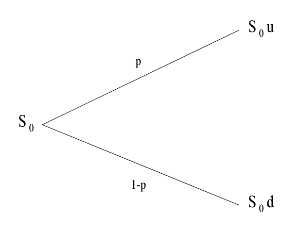

Modèle binomial à une période

## 6.2 Définition d’un portefeuille et du processus de richesse associé

Portefeuille

Un portefeuille est un couple $(x, \pi) \in \mathbb{R}^+ \times \mathbb{R}$ où :

- $x$ représente le capital initial de l’agent à $t=0$
- $\pi$ désigne le nombre d’actions risquées $S$ qu’elle décide de détenir

Processus de Richesse

Pour un portefeuille $(x, \pi)$, le processus de richesse est défini par :
$$\begin{cases}
X_0^{(x,\pi)} = x & \text{(richesse initiale à } t=0\text{)} \\[8pt]
X_1^{(x,\pi)} = \pi S_1 + (x - \pi S_0)(1+r) & \text{(richesse
finale à } t=1\text{)}
\end{cases}$$

**À $t=0$** :

- L’investisseur commence avec $x€$
- Elle achète $\pi$ actions $S$ au prix $S_0$
- Le solde non investi : $x - \pi S_0$

**À $t=1$** :

- La composante risquée vaut : $\pi S_1$ (valeur aléatoire des actions)
- La composante sans risque vaut : $(x - \pi S_0)(1+r)$ (capital placé à taux $r$ avec intérêts)

On note que dans cette définition le portefeuille est **autofinancé** :

- Tout capital non investi dans l’actif risqué $S$ est **automatiquement placé** dans l’actif sans risque $S^0$
- Les seuls flux proviennent des rendements de $S$ et $S^0$

## 6.3 Prix et Richesse Actualisés

Comme démontré dans la section sur l’actualisation, la **valeur temporelle de l’argent** est fondamentale en finance. Dans le modèle binomial, nous choisissons l’actif sans risque $S^0$ comme **numéraire** de référence pour actualiser.

Prix Actualisé

Le processus de prix actualisé de l’actif risqué $S$ est défini par :
$$\begin{cases}
\widetilde{S}_0 = S_0 & \text{(prix actuel non actualisé)} \\[8pt]
\widetilde{S}_1 = \dfrac{S_1}{1+r} & \text{(prix futur actualisé)}
\end{cases}$$

Richesse Actualisée

La richesse actualisée d’un portefeuille $(x, \pi)$ est définie par :
$$\widetilde{X}_t^{(x,\pi)} = \dfrac{X_t^{(x,\pi)}}{(1+r)^t}, \quad t =
0,1$$

Un calcul direct donne une autre expression de la richesse actualisée:

$$\begin{aligned}
\widetilde{X}_1^{(x,\pi)} &= \frac{X_1^{(x,\pi)}}{1+r} \\
&= \frac{\pi S_1 + (x - \pi S_0)(1+r)}{1+r} \\
&= \pi \frac{S_1}{1+r} + (x - \pi S_0) \\
&= \pi \widetilde{S}_1 + (x - \pi S_0) \\
&= x + \pi(\widetilde{S}_1 - \widetilde{S}_0)
\end{aligned}$$

**Formule finale** :
$$\widetilde{X}_1^{(x,\pi)} = x + \pi(\widetilde{S}_1 - \widetilde{S}_0)$$

## 6.4 Notion d’arbitrage

Rappelons la définition : Une opportunité d’arbitrage (AO) est un portefeuille de la forme $(0, \pi)$ tel que :

- Capital initial nul : $x = 0$ : La stratégie ne nécessite aucun investissement personnel au départ
- $\mathbb{P}[X_1^{(0,\pi)} \geq 0] = 1$ : Il n’y a aucun risque de perte.
- $\mathbb{P}[X_1^{(0,\pi)} > 0] > 0$ : la stratégie génère un profit strictement positif. Autrement dit, elle offre une chance réelle de gagner de l’argent.

Notons que : La stratégie triviale $(0, 0)$ n’est pas une opportunité d’aribtrage

Nous pouvons à présent définir l’**Hypothèse d’Absence d’Opportunité d’Arbitrage (AA0)** :

Marché Sans Arbitrage (AAO)

Un marché financier est **sans arbitrage** si, pour toute stratégie d’investissement autofinancée **avec capital initial nul** ($X_0 = 0$), on a la propriété suivante :

**Si** la stratégie ne présente **aucun risque de perte** :
$$\mathbb{P}[X_T \ge 0] =
1$$

**Alors** cette stratégie ne peut **pas générer de profit** non plus :
$$\mathbb{P}[X_T =
0] = 1$$

En d’autres termes : **Une stratégie sans risque et sans capital initial ne peut pas être rentable.**

### 6.4.1 Quelles conditions sur les paramètres garantissent l’AAO ?

Équivalence Fondamentale et Pricing

Les trois assertions suivantes sont **équivalentes** :

**(i) Absence d’arbitrage**  
Le marché est sans opportunité d’arbitrage.

**(ii) Existence d’une mesure martingale équivalente**
Il existe une unique mesure de probabilité $\mathbb{P}^*$ équivalente à $\mathbb{P}$ telle que :
$$\mathbb{E}^{\mathbb{P}^*} \left[ \frac{S_1}{1+r}
\right] = S_0$$
c’est-à-dire que le prix actualisé $\widetilde{S}_t = S_t/(1+r)^t$ est une martingale sous $\mathbb{P}^*$.

**(iii) Condition sur les paramètres**
Les paramètres satisfont la double inégalité :
$$d < 1 + r < u$$

**Preuve (i) ⇔ (iii)**.

1. Condition Nécessaire

Supposons que la relation $d < 1+r < u$ ne soit pas satisfaite. Cela signifie que soit $d \ge 1+r$, soit $1+r \ge u$.

Cas $1+r \ge u$ : La valeur maximale de l’actif risqué est inférieure ou égale au rendement du bon sans risque.

Considérons la stratégie $(x=0, \pi=-1)$ (vente à découvert).

La richesse terminale est : $X_1^{(0,\pi)} = S_0(1+r-C) \ge S_0(1+r-u) \ge 0$

Si $1+r > u$, alors $\mathbb{P}[X_1^{(0,\pi)} > 0] = \mathbb{P}[1+r-C > 0] \ge \mathbb{P}[C=u] = p > 0$

Si $1+r = u$, alors $\mathbb{P}[X_1^{(0,\pi)} > 0] = \mathbb{P}[1+r-C > 0] \ge \mathbb{P}[C=d] = 1-p > 0$

Cas $1+r \le d$ : Le rendement sans risque est inférieur au pire scénario de l’actif risqué.

On choisit $(x=0, \pi=1)$.

Si $1+r < d$, alors $\mathbb{P}[X_1^{(0,1)} > 0] = \mathbb{P}[C-(1+r) > 0] \ge \mathbb{P}[C=d] = 1-p > 0$

Si $1+r = d$, alors $\mathbb{P}[X_1^{(0,1)} > 0] = \mathbb{P}[C-(1+r) > 0] \ge \mathbb{P}[C=u] = p > 0$

Conclusion : Dans les deux cas, $(0, \pi)$ est une opportunité d’arbitrage (AO). La condition $d < 1+r < u$ est donc nécessaire pour éviter l’arbitrage.

2. Condition Suffisante

Supposons maintenant que $d < 1+r < u$ soit vérifiée et qu’il existe une AO $(0, \pi)$.

La richesse est donnée par $X_1^{(x,\pi)} = S_0\pi(C-(1+r))$.

Si $\pi > 0$ : Puisque $\mathbb{P}[X_1^{(x,\pi)} \ge 0] = 1$, il faudrait que $\mathbb{P}[C-(1+r) \ge 0] = 1$, ce qui contredit $1+r < u$.

Si $\pi < 0$ : Un argument similaire montre que cela contredit $d < 1+r$.

Si $\pi = 0$ : Le portefeuille $(0,0)$ n’est pas une AO.

Conclusion : Aucune AO n’existe sous la condition $d < 1+r < u$, qui est donc suffisante.

**Interprétation Intuitive de l’équivalence (i) ⇔ (iii)**

La condition $d < 1+r < u$ signifie que l’actif risqué $S$ est effectivement plus risqué que l’actif sans risque $S^0$, tout en offrant un rendement potentiel plus élevé:

- **$u > 1+r$** : La valeur haute de l’actif risqué dépasse celle du bon, ce qui justifie la prise de risque pour l’investisseur.
- **$d < 1+r$** : L’actif risqué peut prendre des valeurs inférieures à l’actif sans risque, ce qui définit la notion de risque (perte potentielle par rapport au placement sûr).

Unicité du Prix

Le prix $x$ obtenu est **unique**. En effet :

1. Le système de réplication a une **solution unique** $(x, \pi)$
2. Tout autre prix créerait une **opportunité d’arbitrage**
3. Ce prix ne dépend **pas des probabilités réelles $p$**, seulement de $p^*$

Prix d’Arbitrage et Stratégie de Couverture

Soit un contrat financier dont le **payoff** à $t=1$ est modélisé par une variable aléatoire $h$.

**1. Prix d’arbitrage** : Le prix équitable $\overline{x}$ à $t=0$ est donné par l’espérance actualisée sous $\mathbb{P}^*$ :
$$\overline{x} = \frac{1}{1+r}
\mathbb{E}^{\mathbb{P}^*}[h] = \frac{1}{1+r} \left[ p^* h^+ + (1-p^*)
h^- \right]$$

**2. Stratégie de réplication (hedging)** : La stratégie de couverture $\overline{\pi}$ qui permet de répliquer exactement le payoff est :
$$\overline{\pi} = \frac{h^- - h^+}{S_1(d) -
S_1(u)}$$
où $S_1(u) = S_0 u$ et $S_1(d) = S_0 d$.

**Preuve**.

Soit un produit dérivé dont le payoff à $t=1$ est $h$. Dans notre modèle binomial, $h$ peut prendre deux valeurs : - $h^+ = h(S_0 u)$ : Payoff en cas de **hausse** - $h^- = h(S_0 d)$ : Payoff en cas de **baisse**

Nous cherchons un portefeuille $(x, \pi)$ qui **réplique exactement** ce payoff :

$$X_1^{(x,\pi)} = h \quad \text{dans les
deux états du monde}$$

Pour répliquer $h$ dans tous les états, nous devons avoir :

**Système à résoudre :**

$$\begin{cases}
\pi S_0 u + (x - \pi S_0)(1+r) = h^+ & \text{(équation H : état
hausse)} \\[8pt]
\pi S_0 d + (x - \pi S_0)(1+r) = h^- & \text{(équation T : état
baisse)}
\end{cases}$$

Soustrayons l’équation (T) de l’équation (H) pour éliminer $x$.

$$\begin{aligned}
[\pi S_0 u + (x - \pi S_0)(1+r)] - [\pi S_0 d + (x - \pi S_0)(1+r)]
&= h^+ - h^- \\
\pi S_0 u - \pi S_0 d &= h^+ - h^- \\
\pi S_0 (u - d) &= h^+ - h^- \\
\end{aligned}$$

**Solution unique pour $\pi$ :**
$$\boxed{\pi = \frac{h^+ -
h^-}{S_0(u - d)}}$$

Ce $\pi$ représente le **nombre d’actions risquées** nécessaires pour couvrir parfaitement le payoff $h$.

Résolvons maintenant pour $x$ à partir de l’équation (H).

**Partons de l’équation (H) :**
$$\pi S_0 u + (x - \pi S_0)(1+r) = h^+$$

**Isolons $x$ :**
$$\begin{aligned}
x - \pi S_0 &= \frac{h^+ - \pi S_0 u}{1+r} \\
x &= \pi S_0 + \frac{h^+ - \pi S_0 u}{1+r}
\end{aligned}$$

**Substituons l’expression de $\pi$ :**
$$\begin{aligned}
x &= \frac{h^+ - h^-}{u - d} + \frac{1}{1+r} \left[ h^+ - \frac{h^+
- h^-}{u - d} u \right] \\
&= \frac{h^+ - h^-}{u - d} + \frac{1}{1+r} \left[ \frac{h^+(u - d) -
u(h^+ - h^-)}{u - d} \right] \\
&= \frac{h^+ - h^-}{u - d} + \frac{1}{1+r} \left[ \frac{h^+ u - h^+
d - h^+ u + u h^-}{u - d} \right] \\
&= \frac{h^+ - h^-}{u - d} + \frac{1}{1+r} \left[ \frac{u h^- - h^+
d}{u - d} \right] \\
&= \frac{1}{1+r} \left[ \frac{(1+r)(h^+ - h^-) + u h^- - h^+ d}{u -
d} \right] \\
&= \frac{1}{1+r} \left[ \frac{h^+[(1+r) - d] + h^-[u - (1+r)]}{u -
d} \right] \\
\end{aligned}$$

**Forme finale :**
$$\boxed{x = \frac{1}{1+r} \left[ h^+ \cdot \frac{(1+r) - d}{u - d} + h^-
\cdot \frac{u - (1+r)}{u - d} \right] }$$

**Définissons :**
$$p^* :=
\frac{(1+r) - d}{u - d}$$

**Sous la condition d’absence d’arbitrage $d < 1+r < u$, on vérifie que :**

- $0 < p^* < 1$
- $1 - p^* = \frac{u - (1+r)}{u - d}$

**La formule pour $x$ devient alors :**
$$\boxed{x =
\frac{1}{1+r} \left[ p^* h^+ + (1-p^*) h^- \right] }$$

**Ce qui s’écrit comme une espérance :**
$$x = \frac{1}{1+r} \mathbb{E}^{\mathbb{P}^*}[h]$$
où $\mathbb{P}^*$ est la **mesure neutre au risque** définie par $\mathbb{P}^*(H) = p^*$.

# 7 Modèles de marchés à temps discret et mesures martingales équivalentes (Généralisation à T périodes)

Dans la partie 6, nous avons étudié un modèle binomial à une période, qui constitue un cadre simple pour introduire la notion d’analyse des marchés financiers. Dans ce modèle, nous avons vu que l’absence d’opportunité d’arbitrage est équivalente à l’existence d’une *unique mesure martingale équivalente* $\mathbb{P}^*$, sous laquelle le prix actualisé de l’actif risqué est une martingale. Cette propriété permet alors d’exprimer le prix d’arbitrage d’un contrat financier comme l’espérance actualisée de son payoff sous $\mathbb{P}^*$, et d’en déduire explicitement une stratégie de réplication.

Ce résultat met en évidence un lien entre absence d’arbitrage, réplication et martingales. Cependant, il repose sur un cadre très particulier : un modèle à une seule période, avec deux d’états du monde.

## 7.1 Cadre probabiliste et modélisation du marché

### 7.1.1 Structure probabiliste et filtration

On considère un espace de probabilité fini
$$(\Omega, F, \mathbb{P}),$$
où $\Omega$ représente l’ensemble des états du monde, $F$ l’ensemble des événements observables, et $\mathbb{P}$ la probabilité réelle (historique) associée aux événements.

Filtration

Une filtration est une famille croissante de sous-tribus
$$(F_t)_{t=0,\dots,T}$$
telle que
$$F_0 \subset F_1 \subset \cdots \subset F_T = F.$$

Chaque tribu $F_t$ représente l’ensemble des informations disponibles à la date $t$. En particulier, $F_0 = \{\varnothing, \Omega\}$ correspond à l’absence d’information initiale.

Cette structure permet de modéliser l’évolution de l’information au cours du temps et impose que toute stratégie financière ne puisse dépendre que de l’information disponible au moment où les décisions sont prises.

### 7.1.2 Modèle de Marché en Temps Discret

Marché financier

Le marché contient deux types d’actifs :

1. **Actif sans risque** (obligation) :
   $$B_t = (1+r)^t$$
   où $r$ est le taux d’intérêt sans risque.

L’obligation représente un placement sûr, comme un compte épargne. Sa valeur est certaine et croît exponentiellement avec le temps. C’est notre “référence” pour mesurer la valeur de l’argent.

2. **Actifs risqués** (actions) :
   $$S_t = (S^1_t, \dots, S^d_t)$$
   où $S_t$ est $F_t$-mesurable (prix connu à l’instant $t$).

Les actions ont des prix incertains qui évoluent aléatoirement. Leur valeur future n’est pas connue à l’avance. L’hypothèse “$S_t$ est $F_t$-mesurable” signifie simplement qu’à l’instant $t$, le prix $S_t$ est observé et fait partie de l’information disponible.

Cette distinction entre actif sûr et actifs risqués reflète la réalité des marchés financiers. Les investisseurs ont toujours le choix entre un placement sans risque (mais avec rendement faible) et des placements risqués (avec potentiel de gain plus élevé, mais aussi de perte).

### 7.1.3 Contrainte d’informations et stratégie d’auto-financement

Dans la modélisation de notre marché, une contrainte de réalisme est posée : la décision d’acheter ou de vendre des actions à l’instant $t$ doit se faire avant de voir les nouveaux prix, c’est-à-dire qu’elle s’appuie sur l’information disponible juste avant $t$. C’est ce qu’on appelle une stratégie prévisible.

Stratégie Prévisible

Une stratégie $\pi = (\pi_t)_{t=1,\dots,T}$ est **prévisible** si
$$\pi_t \text{ est } F_{t-1}\text{-mesurable}.$$

Nous imposons que les portefeuilles soient **auto-financés**, c’est-à-dire qu’aucun apport ni retrait d’argent n’intervienne entre la date initiale et la date finale.

Portefeuille auto-financé

Un portefeuille est auto-financé si sa valeur $X_t$ satisfait :
$$X_t = \pi_t \cdot S_t + \text{(position en obligations)}$$

**Forme équivalente avec prix actualisés** :
$$\widetilde{X}_t = \widetilde{X}_{t-1} + \pi_t \cdot (\widetilde{S}_t -
\widetilde{S}_{t-1})$$
où $\widetilde{S}_t$ et $\widetilde{X}_t$ sont les prix et valeurs actualisés.

C’est-à-dire qu’ils sont exprimés en unités de l’actif sans risque :
$$\widetilde{S}_t := \frac{S_t}{B_t} = \frac{S_t}{(1+r)^t}$$

La valeur actualisée d’un portefeuille est :
$$\widetilde{X}_t = \frac{X_t}{B_t}$$

## 7.2 Théorème Fondamental de l’Évaluation d’Actifs et Contigents répliquables

### 7.2.1 Mesure Martingale Équivalente

Mesure Martingale Équivalente

Une probabilité $P^*$ est une MME si :

1. **Équivalence** : $P^* \sim P$ (mêmes événements possibles)
2. **Propriété martingale** :
   $$\mathbb{E}^{P^*}[\widetilde{S}_t \mid F_{t-1}] = \widetilde{S}_{t-1}$$

Sous $P^*$, les prix actualisés des actifs risqués n’ont pas de tendance (leur espérance conditionnelle est égale à leur valeur actuelle).

### 7.2.2 Premier Théorème Fondamental de l’Évaluation d’Actifs

Ce théorème établit un lien entre la finance et les mathématiques. Il montre que l’absence d’arbitrage (condition économique réaliste) est mathématiquement équivalente à l’existence d’une probabilité $P^*$ sous laquelle les prix actualisés suivent une martingale.

Théorème Fondamental (Premier Théorème de l’Évaluation d’Actifs)

Dans un marché financier en temps discret, les deux conditions suivantes sont équivalentes :

1. **Absence d’opportunités d’arbitrage**
2. **Existence d’une mesure martingale équivalente (MME)** $P^*$

$$\boxed{
\text{Marché sans arbitrage}
\Longleftrightarrow
\exists P^* \text{ (mesure martingale équivalente)}
}$$

Ce théorème se trouve au coeur de la théorie moderne du pricing des produits dérivés. Il permet de calculer des prix théoriques en utilisant uniquement des calculs d’espérance sous $P^*$.

### 7.2.3 Prix des produits financiers réplicables

En finance, un produit financier est un actif dont la valeur future dépend de l’évolution d’autres actifs. Lorsqu’un tel produit peut être reproduit exactement par une combinaison d’actifs déjà présents sur le marché, on dit qu’il est **réplicable**.

Produit Réplicable

Un produit financier (comme une option) est dit **réplicable** si on peut créer un portefeuille qui reproduit exactement son payoff à maturité.

**Définition formelle** : Un payoff $h$ (à maturité $T$) est réplicable s’il existe une stratégie auto-financée $\pi$ telle que :
$$X_T(\pi) = h$$
où $X_T(\pi)$ est la valeur du portefeuille à maturité $T$.

Cette définition signifie qu’il existe une stratégie de trading (un plan d’achat/vente d’actions et d’obligations au cours du temps) qui, avec un certain capital initial, permet d’obtenir exactement le même gain que le produit financier à maturité.

Lorsqu’un produit est réplicable, l’absence d’arbitrage impose que son prix soit unique.

Théorème de Pricing des produits Réplicables

Si un produit de payoff $h$ est réplicable, alors son prix d’arbitrage à l’instant $t$ est unique et donné par :

$$\boxed{
\text{Prix}_t = B_t \cdot \mathbb{E}^{P^*}\left[ \frac{h}{B_T}
\;\middle|\; F_t \right]
}$$
où $P^*$ est **n’importe quelle** mesure martingale équivalente.

**Cas particulier (prix initial)** :
$$\text{Prix}_0 = \frac{1}{(1+r)^T} \mathbb{E}^{P^*}[h]$$

Ce résultat fondamental établit que le pricing des produits dérivés réplicables se réduit à un calcul d’espérance sous une MME. La MME permet de calculer des prix ‘neutres au risque’ en procédant à une réplication dynamique elles transforment une position risquée en une position couverte. C’est le fondement de nombreuses méthodes d’évaluation en finance , permettant de déterminer des prix théoriques cohérents avec l’hypothèse de marchés sans opportunités d’arbitrage.

# 8 Principe de programmation dynamique : Modèle Modèle de Cox-Ross-Rubinstein (à T périodes)

## 8.1 1. Introduction et Principe Général

On généralise le modèle de **Cox-Ross-Rubinstein** (ou **modèle binomial**) sur plusieurs périodes.Le modèle de **Cox-Ross-Rubinstein** est une méthode numérique utilisée pour évaluer des options financières.  
Il repose sur la discrétisation du temps en $N$ périodes.

L’hypothèse fondamentale est qu’à chaque étape de temps, le prix de l’actif sous-jacent $S$ ne peut évoluer que de deux manières :

- **Une hausse (Up)** : multiplié par un facteur $u$
- **Une baisse (Down)** : multiplié par un facteur $d$

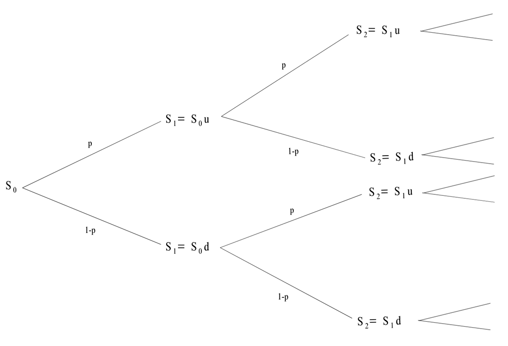

Modèle Binomial à T périodes

L’objectif du code fourni est de construire cet *arbre* de prix possibles, puis de remonter le temps (**récurrence**) pour déterminer la valeur de l’option à l’instant initial $t = 0$. C’est le principe de la programmation dynamique.

Théorème de Programmation Dynamique

Dans le modèle binomial à $T$ périodes, le prix d’une option de payoff $h = g(S_T)$ peut être calculé par récurrence arrière :

1. **Prix à maturité** :
   $$g_T(x) = g(x)$$
2. **Récurrence arrière** (pour $t = T-1, T-2, \dots, 0$) :
   $$g_t(x) = p^* g_{t+1}(xu) + (1-p^*) g_{t+1}(xd)$$
3. **Prix à l’instant $t$** :
   $$\rho_t = (1+r)^{-(T-t)} g_t(S_t)$$
4. **Stratégie de réplication** : La couverture dynamique est donnée par :
   $$\pi_t = (1+r)^{-(T-t)} \varphi_t(S_{t-1})$$
   avec
   $$\varphi_t(x) = \frac{g_t(xu) - g_t(xd)}{x(u-d)}$$

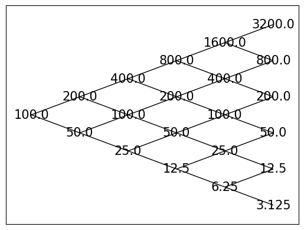

Exemple d’arbre binomial pour S₀=100 et p=0.5

## 8.2 La Démarche Récursive : *Backward Induction*

Le cœur du TP réside dans la fonction `option_price`.  
La méthode fonctionne en deux phases distinctes :

- Phase **Forward** (construction)
- Phase **Backward** (évaluation)

### 8.2.1 Phase 1 : Construction de l’Arbre de l’Actif (*Forward*)

On part du prix initial $S_0$ et on projette les prix futurs jusqu’à la maturité $T$.

Dans la fonction `graph_stock` du notebook :

- À l’étape $0$, on a :

$$S_{0,0} = S_0$$

- À l’étape $n$, pour chaque nœud $j$, on calcule les nœuds de l’étape $n+1$ :

$$S_{n+1, j} = S_{n, j} \cdot u \quad \text{(hausse)}$$

$$S_{n+1, j+1} = S_{n, j} \cdot d \quad \text{(baisse)}$$

Cette construction permet d’obtenir tous les prix possibles de l’actif sous-jacent jusqu’à la maturité.

### 8.2.2 Phase 2 : Évaluation de l’Option (*Backward – Récursif*)

C’est ici que la logique de **pricing** intervient.  
On ne peut pas calculer directement le prix de l’option à $t = 0$, car il dépend des valeurs futures.

On utilise donc le principe de **programmation dynamique**.

#### 8.2.2.1 Condition Terminale (Maturité $N$)

On se place tout à la fin de l’arbre (au temps $T$).  
À cette date, le prix de l’option est connu avec certitude : c’est son **payoff**.

Pour une option **Call** on retourne :

$$max(x-K,0)$$

#### 8.2.2.2 Récurrence de (N-1) à 0

Une fois les valeurs connues à l’étape $n+1$, on peut calculer la valeur à l’étape $n$.

Le prix de l’option à un nœud est l’espérance actualisée des valeurs futures possibles, pondérées par la probabilité risque-neutre $p$.

La formule de récurrence utilisée dans la boucle est:

$$\rho_t = (1+r)^{-(T-t)} \mathbb{E}^{\mathbb{P}^*} [h \mid F_t]$$

### 8.2.3 Résultat

Après simulation on obtient l’arbre suivant.

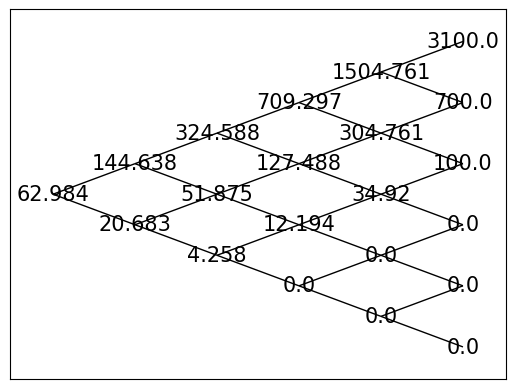

Arbre binomial après simulation

Pour un strike de valeur 100, le prix à t=0 pour un call Européen vaut environ 63 euros.

On peut réaliser les même simulation pour d’autres options comme un Put.

# 9 Conclusion et Ouverture

Ce travail nous a permis de voir une première approche pour déterminer le “juste prix” d’une action financière et se protéger contre le risque d’un environnement incertain.

À travers le modèle de Cox-Ross-Rubinstein (CRR), nous avons montré que l’évaluation d’un produit dérivé ne repose pas sur les probabilités réelles de hausse ou de baisse du marché, mais sur un principe d’**absence d’opportunité d’arbitrage**. En construisant un arbre binomial, nous avons vu qu’il est possible de dupliquer les flux de l’option grâce à un portefeuille de couverture (hedging) composé de l’actif risqué et de l’actif sans risque.

Notre implémentation numérique a validé la méthode de “programmation dynamique”, confirmant que le prix de l’option à l’instant $t=0$ correspond à l’espérance de ses flux futurs actualisés sous une probabilité unique : la **probabilité risque-neutre** $\mathbb{P}^*$.

Si le modèle CRR est puissant par sa simplicité et sa flexibilité numérique, il reste une approximation discrète de la réalité des marchés financiers qui sont, eux, continus.

Il existe cependant un lien fondamental entre notre approche discrète et les modèles continus utilisés en salle de marché. Lorsque l’on augmente le nombre de périodes $N$ vers l’infini (faisant tendre le pas de temps $\Delta t$ vers 0), l’arbre binomial converge vers une distribution log-normale des prix.

Mathématiquement, la limite de la formule de Cox-Ross-Rubinstein correspond exactement à la célèbre **formule de Black-Scholes (1973)**. Le modèle binomial peut donc être vu comme la discrétisation naturelle du mouvement brownien géométrique utilisé par Black et Scholes. Cette convergence justifie l’utilisation du modèle CRR non seulement comme outil pédagogique, mais aussi comme méthode numérique robuste pour valoriser des options complexes (comme les options Américaines) là où les formules fermées de Black-Scholes atteignent leurs limites (suppose que l’option ne peut être exercée qu’à maturité).